# Project: Investigate a Dataset (No Show Appointments)

- Introduction
- Data Wrangling
- Exploratory Data Analysis
- Conclusions

## Introduction

> This dataset collects information from 100k medical appointments in Brazil and is focused on the question of whether or not patients show up for their appointment. A number of characteristics about the patient are included in each row.

> First, I will investigate the size of the problem. Second,I will investigate each characteristic and its coorrelation with not showing up to an appointment in a form of a research question about each characteristic and its impact on the problem of not showing. Third,I'll investigate the impact of the waiting duration and the clinic crowded days on the patient not showing.

### Questions

1. How big is the problem?, in other words, How many patients didn't show up to their appointment?
2. Do SMS reminders decrease the number of absences?
3. How is age affecting the patient's absence? (Age groups classification)
4. Are chronic illnesses like hypertension and diabetes affecting patient's absences?
5. Is alcoholism a prominent factor in patient's absences? Are the absences frequent?
6. Do disabilities affect patient's absences
7. Are no-show appointments associated with a certain gender?
8. Do patients who don't have scholarships affect their absences
9. Is the period between scheduled day and appointment day affecting the number of no-show appointments?
10. Do patients tend to skip their appointment if the clinic is crowded?

```python
#Here is the set up import statements for all of the packages used
import pandas as pd
import numpy as np
from datetime import date
from datetime import datetime as dt
import matplotlib.pyplot as plt
%matplotlib inline
import seaborn as sns
```

## Data Wrangling

> First, loading the data from the csv file into a dataframe. Second, assessing the data for cleanliness.Third, cleaning the data

### Loading the data into the dataset

```python
# Load the data and print out a few lines.

df=pd.read_csv('no-show-app.csv')
df.head()
```

|  | PatientId | AppointmentID | Gender | ScheduledDay | AppointmentDay | Age | Neighbourhood | Scholarship | Hipertension | Diabetes | Alcoholism | Handcap | SMS_received | No-show |
| --- | --- | --- | --- | --- | --- | --- | --- | --- | --- | --- | --- | --- | --- | --- |
| 0 | 2.987250e+13 | 5642903 | F | 2016-04-29T18:38:08Z | 2016-04-29T00:00:00Z | 62 | JARDIM DA PENHA | 0 | 1 | 0 | 0 | 0 | 0 | No |
| 1 | 5.589978e+14 | 5642503 | M | 2016-04-29T16:08:27Z | 2016-04-29T00:00:00Z | 56 | JARDIM DA PENHA | 0 | 0 | 0 | 0 | 0 | 0 | No |
| 2 | 4.262962e+12 | 5642549 | F | 2016-04-29T16:19:04Z | 2016-04-29T00:00:00Z | 62 | MATA DA PRAIA | 0 | 0 | 0 | 0 | 0 | 0 | No |
| 3 | 8.679512e+11 | 5642828 | F | 2016-04-29T17:29:31Z | 2016-04-29T00:00:00Z | 8 | PONTAL DE CAMBURI | 0 | 0 | 0 | 0 | 0 | 0 | No |
| 4 | 8.841186e+12 | 5642494 | F | 2016-04-29T16:07:23Z | 2016-04-29T00:00:00Z | 56 | JARDIM DA PENHA | 0 | 1 | 1 | 0 | 0 | 0 | No |

### Primary Data Investigation

Checking data size, type and missing values

```python
#Inspect data size
df.shape
```

```
(110527, 14)
```

```python
# Inspect data types
df.dtypes
```

```
PatientId         float64
AppointmentID       int64
Gender             object
ScheduledDay       object
AppointmentDay     object
Age                 int64
Neighbourhood      object
Scholarship         int64
Hipertension        int64
Diabetes            int64
Alcoholism          int64
Handcap             int64
SMS_received        int64
No-show            object
dtype: object
```

```python
#look for instances of missing data
df.isnull().sum().sum()
```

```
0
```

```python
#Check for dulplicates
df.duplicated().value_counts()
```

```
False    110527
dtype: int64
```

```python
#Data Statistics
df.describe()
```

|  | PatientId | AppointmentID | Age | Scholarship | Hipertension | Diabetes | Alcoholism | Handcap | SMS_received |
| --- | --- | --- | --- | --- | --- | --- | --- | --- | --- |
| count | 1.105270e+05 | 1.105270e+05 | 110527.000000 | 110527.000000 | 110527.000000 | 110527.000000 | 110527.000000 | 110527.000000 | 110527.000000 |
| mean | 1.474963e+14 | 5.675305e+06 | 37.088874 | 0.098266 | 0.197246 | 0.071865 | 0.030400 | 0.022248 | 0.321026 |
| std | 2.560949e+14 | 7.129575e+04 | 23.110205 | 0.297675 | 0.397921 | 0.258265 | 0.171686 | 0.161543 | 0.466873 |
| min | 3.921784e+04 | 5.030230e+06 | -1.000000 | 0.000000 | 0.000000 | 0.000000 | 0.000000 | 0.000000 | 0.000000 |
| 25% | 4.172614e+12 | 5.640286e+06 | 18.000000 | 0.000000 | 0.000000 | 0.000000 | 0.000000 | 0.000000 | 0.000000 |
| 50% | 3.173184e+13 | 5.680573e+06 | 37.000000 | 0.000000 | 0.000000 | 0.000000 | 0.000000 | 0.000000 | 0.000000 |
| 75% | 9.439172e+13 | 5.725524e+06 | 55.000000 | 0.000000 | 0.000000 | 0.000000 | 0.000000 | 0.000000 | 1.000000 |
| max | 9.999816e+14 | 5.790484e+06 | 115.000000 | 1.000000 | 1.000000 | 1.000000 | 1.000000 | 4.000000 | 1.000000 |

```python
#Data Info
df.info()
```

```
<class 'pandas.core.frame.DataFrame'>
RangeIndex: 110527 entries, 0 to 110526
Data columns (total 14 columns):
PatientId         110527 non-null float64
AppointmentID     110527 non-null int64
Gender            110527 non-null object
ScheduledDay      110527 non-null object
AppointmentDay    110527 non-null object
Age               110527 non-null int64
Neighbourhood     110527 non-null object
Scholarship       110527 non-null int64
Hipertension      110527 non-null int64
Diabetes          110527 non-null int64
Alcoholism        110527 non-null int64
Handcap           110527 non-null int64
SMS_received      110527 non-null int64
No-show           110527 non-null object
dtypes: float64(1), int64(8), object(5)
memory usage: 11.8+ MB
```

### Conclusion of Primary Data Investigation

After a primary data exploration, there is no missing values nor duplicates. But we need to lowercase all the column labels for ease of reference and rename the Hipertension and Handcapped columns since they are mistyped.

### Secondary Data Investigation

Next, we will check if there is any errant data by investigating all values in all columns except those in the patient id and the appointment id.

```python
#Get the Columns Labels for the next investigation
df.columns
```

```
Index(['PatientId', 'AppointmentID', 'Gender', 'ScheduledDay',
       'AppointmentDay', 'Age', 'Neighbourhood', 'Scholarship', 'Hipertension',
       'Diabetes', 'Alcoholism', 'Handcap', 'SMS_received', 'No-show'],
      dtype='object')
```

```python
#check for data validation
check_values=[df[col].unique() for col in df if col in ['Gender', 'ScheduledDay',
       'AppointmentDay', 'Age', 'Neighbourhood', 'Scholarship', 'Hipertension',
       'Diabetes', 'Alcoholism', 'Handcap', 'SMS_received', 'No-show']]
check_values
```

```
[array(['F', 'M'], dtype=object),
 array(['2016-04-29T18:38:08Z', '2016-04-29T16:08:27Z',
        '2016-04-29T16:19:04Z', ..., '2016-04-27T16:03:52Z',
        '2016-04-27T15:09:23Z', '2016-04-27T13:30:56Z'], dtype=object),
 array(['2016-04-29T00:00:00Z', '2016-05-03T00:00:00Z',
        '2016-05-10T00:00:00Z', '2016-05-17T00:00:00Z',
        '2016-05-24T00:00:00Z', '2016-05-31T00:00:00Z',
        '2016-05-02T00:00:00Z', '2016-05-30T00:00:00Z',
        '2016-05-16T00:00:00Z', '2016-05-04T00:00:00Z',
        '2016-05-19T00:00:00Z', '2016-05-12T00:00:00Z',
        '2016-05-06T00:00:00Z', '2016-05-20T00:00:00Z',
        '2016-05-05T00:00:00Z', '2016-05-13T00:00:00Z',
        '2016-05-09T00:00:00Z', '2016-05-25T00:00:00Z',
        '2016-05-11T00:00:00Z', '2016-05-18T00:00:00Z',
        '2016-05-14T00:00:00Z', '2016-06-02T00:00:00Z',
        '2016-06-03T00:00:00Z', '2016-06-06T00:00:00Z',
        '2016-06-07T00:00:00Z', '2016-06-01T00:00:00Z',
        '2016-06-08T00:00:00Z'], dtype=object),
 array([ 62,  56,   8,  76,  23,  39,  21,  19,  30,  29,  22,  28,  54,
         15,  50,  40,  46,   4,  13,  65,  45,  51,  32,  12,  61,  38,
         79,  18,  63,  64,  85,  59,  55,  71,  49,  78,  31,  58,  27,
          6,   2,  11,   7,   0,   3,   1,  69,  68,  60,  67,  36,  10,
         35,  20,  26,  34,  33,  16,  42,   5,  47,  17,  41,  44,  37,
         24,  66,  77,  81,  70,  53,  75,  73,  52,  74,  43,  89,  57,
         14,   9,  48,  83,  72,  25,  80,  87,  88,  84,  82,  90,  94,
         86,  91,  98,  92,  96,  93,  95,  97, 102, 115, 100,  99,  -1]),
 array(['JARDIM DA PENHA', 'MATA DA PRAIA', 'PONTAL DE CAMBURI',
        'REPÚBLICA', 'GOIABEIRAS', 'ANDORINHAS', 'CONQUISTA',
        'NOVA PALESTINA', 'DA PENHA', 'TABUAZEIRO', 'BENTO FERREIRA',
        'SÃO PEDRO', 'SANTA MARTHA', 'SÃO CRISTÓVÃO', 'MARUÍPE',
        'GRANDE VITÓRIA', 'SÃO BENEDITO', 'ILHA DAS CAIEIRAS',
        'SANTO ANDRÉ', 'SOLON BORGES', 'BONFIM', 'JARDIM CAMBURI',
        'MARIA ORTIZ', 'JABOUR', 'ANTÔNIO HONÓRIO', 'RESISTÊNCIA',
        'ILHA DE SANTA MARIA', 'JUCUTUQUARA', 'MONTE BELO',
        'MÁRIO CYPRESTE', 'SANTO ANTÔNIO', 'BELA VISTA', 'PRAIA DO SUÁ',
        'SANTA HELENA', 'ITARARÉ', 'INHANGUETÁ', 'UNIVERSITÁRIO',
        'SÃO JOSÉ', 'REDENÇÃO', 'SANTA CLARA', 'CENTRO', 'PARQUE MOSCOSO',
        'DO MOSCOSO', 'SANTOS DUMONT', 'CARATOÍRA', 'ARIOVALDO FAVALESSA',
        'ILHA DO FRADE', 'GURIGICA', 'JOANA D´ARC', 'CONSOLAÇÃO',
        'PRAIA DO CANTO', 'BOA VISTA', 'MORADA DE CAMBURI', 'SANTA LUÍZA',
        'SANTA LÚCIA', 'BARRO VERMELHO', 'ESTRELINHA', 'FORTE SÃO JOÃO',
        'FONTE GRANDE', 'ENSEADA DO SUÁ', 'SANTOS REIS', 'PIEDADE',
        'JESUS DE NAZARETH', 'SANTA TEREZA', 'CRUZAMENTO',
        'ILHA DO PRÍNCIPE', 'ROMÃO', 'COMDUSA', 'SANTA CECÍLIA',
        'VILA RUBIM', 'DE LOURDES', 'DO QUADRO', 'DO CABRAL', 'HORTO',
        'SEGURANÇA DO LAR', 'ILHA DO BOI', 'FRADINHOS', 'NAZARETH',
        'AEROPORTO', 'ILHAS OCEÂNICAS DE TRINDADE', 'PARQUE INDUSTRIAL'], dtype=object),
 array([0, 1]),
 array([1, 0]),
 array([0, 1]),
 array([0, 1]),
 array([0, 1, 2, 3, 4]),
 array([0, 1]),
 array(['No', 'Yes'], dtype=object)]
```

#### Note 1 Handicapped Columns

> After Investigting the data above,the Handcap column values are from 0 to 4..At first I thought that the value of this column should be a binary number either 0 or 1. But after refering to Kaggle website and to the creator of this dataset, his reply was that the values from 0 to 4 referes to the number of disabilities patients have( Here is a link of his explanantion https://www.kaggle.com/joniarroba/noshowappointments/discussion/29699)

#### Investigating Age Column

```python
#Investigate how many rows with Age -1
df.query('Age<0')
```

|  | PatientId | AppointmentID | Gender | ScheduledDay | AppointmentDay | Age | Neighbourhood | Scholarship | Hipertension | Diabetes | Alcoholism | Handcap | SMS_received | No-show |
| --- | --- | --- | --- | --- | --- | --- | --- | --- | --- | --- | --- | --- | --- | --- |
| 99832 | 4.659432e+14 | 5775010 | F | 2016-06-06T08:58:13Z | 2016-06-06T00:00:00Z | -1 | ROMÃO | 0 | 0 | 0 | 0 | 0 | 0 | No |

**Note**:I will have to rename the no-show column in this step to be able to access its data

```python
#rename the no-show column
df.rename(columns={'No-show':'no_show'},inplace=True)
df.columns
```

```
Index(['PatientId', 'AppointmentID', 'Gender', 'ScheduledDay',
       'AppointmentDay', 'Age', 'Neighbourhood', 'Scholarship', 'Hipertension',
       'Diabetes', 'Alcoholism', 'Handcap', 'SMS_received', 'no_show'],
      dtype='object')
```

```python
#Investigate how many rows with Age 0
age_0=df.query('Age==0')

#Calculating the percentage of patients with age 0
age_0_percent=age_0.count()[0]/df.count()[0]*100

print('Number of patients with age 0 is {} patient.'.format(age_0.count()[0]))
print('Percentage of patients with age 0 in the dataset is {} %.'.format(round(age_0_percent,2)))
```

```
Number of patients with age 0 is 3539 patient.
Percentage of patients with age 0 in the dataset is 3.2 %.
```

```python
#checking how many patients with Age 0 didn't show
print(age_0.query('no_show=="Yes"').count()[0])

##checking how many patients with Age 0 with Hipertension or Diabetes or Alcoholism
print(age_0.query("Hipertension==1 or Diabetes==1 or Alcoholism==1").count()[0])
```

```
639
0
```

#### Note 2: After Investigating Age Column

> 1. There is a negative value in the Age column, but it's only one row, so we can drop it.
> 2. There are 3539 rows with zero values in the Age column, 639 out of which didn't show up and none of them have diabetes, hypertension or alcoholism. It's uncertain if the zero values are for infants for instance since this column doesn't hold floats, or if this is an errant data. However, I decided to drop these rows since they represent only 3% of the whole data.
> 3. There are eldery patients from age 100 till age 115, this data was a bit suspicious.But after searching, this data cannot be considered errant, since there are verified old people living to this age as per wikipedia; [List of Verified Oldest People.](https://en.wikipedia.org/wiki/List_of_the_verified_oldest_people)

#### Investigating Date Columns.

> Since we have two date columns, one for schedule and one for appointment, we can calculate the waiting duration for the patient from the day he was scheduled to the appointment date, but before we do that we have to check that all the apointment dates are prior to the schedule dates.

```python
#Changing the date columns datatypes to date
df['ScheduledDay']=pd.to_datetime(df['ScheduledDay']).dt.date

#Get the rows with Scheduled Day after the Appointment Day
df['AppointmentDay']=pd.to_datetime(df['AppointmentDay']).dt.date
df.query('ScheduledDay>AppointmentDay')
```

|  | PatientId | AppointmentID | Gender | ScheduledDay | AppointmentDay | Age | Neighbourhood | Scholarship | Hipertension | Diabetes | Alcoholism | Handcap | SMS_received | no_show |
| --- | --- | --- | --- | --- | --- | --- | --- | --- | --- | --- | --- | --- | --- | --- |
| 27033 | 7.839273e+12 | 5679978 | M | 2016-05-10 | 2016-05-09 | 38 | RESISTÊNCIA | 0 | 0 | 0 | 0 | 1 | 0 | Yes |
| 55226 | 7.896294e+12 | 5715660 | F | 2016-05-18 | 2016-05-17 | 19 | SANTO ANTÔNIO | 0 | 0 | 0 | 0 | 1 | 0 | Yes |
| 64175 | 2.425226e+13 | 5664962 | F | 2016-05-05 | 2016-05-04 | 22 | CONSOLAÇÃO | 0 | 0 | 0 | 0 | 0 | 0 | Yes |
| 71533 | 9.982316e+14 | 5686628 | F | 2016-05-11 | 2016-05-05 | 81 | SANTO ANTÔNIO | 0 | 0 | 0 | 0 | 0 | 0 | Yes |
| 72362 | 3.787482e+12 | 5655637 | M | 2016-05-04 | 2016-05-03 | 7 | TABUAZEIRO | 0 | 0 | 0 | 0 | 0 | 0 | Yes |

#### Date Columns Inpection Conclusion.

> We have found 5 rows where the appointment date was before the scheduled date which is of course an invalid data that needs to be dropped.

### Data Cleaning

#### Lower Case All Columns labels

```python
#lowercase all column names
df.rename(columns=lambda x: x.lower(),inplace=True)
#check column labels are lower cased
df.head()
```

|  | patientid | appointmentid | gender | scheduledday | appointmentday | age | neighbourhood | scholarship | hipertension | diabetes | alcoholism | handcap | sms_received | no_show |
| --- | --- | --- | --- | --- | --- | --- | --- | --- | --- | --- | --- | --- | --- | --- |
| 0 | 2.987250e+13 | 5642903 | F | 2016-04-29 | 2016-04-29 | 62 | JARDIM DA PENHA | 0 | 1 | 0 | 0 | 0 | 0 | No |
| 1 | 5.589978e+14 | 5642503 | M | 2016-04-29 | 2016-04-29 | 56 | JARDIM DA PENHA | 0 | 0 | 0 | 0 | 0 | 0 | No |
| 2 | 4.262962e+12 | 5642549 | F | 2016-04-29 | 2016-04-29 | 62 | MATA DA PRAIA | 0 | 0 | 0 | 0 | 0 | 0 | No |
| 3 | 8.679512e+11 | 5642828 | F | 2016-04-29 | 2016-04-29 | 8 | PONTAL DE CAMBURI | 0 | 0 | 0 | 0 | 0 | 0 | No |
| 4 | 8.841186e+12 | 5642494 | F | 2016-04-29 | 2016-04-29 | 56 | JARDIM DA PENHA | 0 | 1 | 1 | 0 | 0 | 0 | No |

#### Dropping rows with the negative and zero value in age

```python
#Drop rows with negative values
age_neg_rows = df[ df['age'] == -1 ].index
df.drop(age_neg_rows,inplace=True)
#Confirm Negative value is deleted
df.query('age==-1')
```

|  | patientid | appointmentid | gender | scheduledday | appointmentday | age | neighbourhood | scholarship | hipertension | diabetes | alcoholism | handcap | sms_received | no_show |
| --- | --- | --- | --- | --- | --- | --- | --- | --- | --- | --- | --- | --- | --- | --- |

```python
#Check data size after deletion
df.shape
```

```
(110526, 14)
```

```python
#Drop rows with zero values
age_zero_rows = df[ df['age'] == 0 ].index
df.drop(age_zero_rows,inplace=True)
#Confirm zero value is deleted
df.query('age==0')
```

|  | patientid | appointmentid | gender | scheduledday | appointmentday | age | neighbourhood | scholarship | hipertension | diabetes | alcoholism | handcap | sms_received | no_show |
| --- | --- | --- | --- | --- | --- | --- | --- | --- | --- | --- | --- | --- | --- | --- |

```python
#Check data size after deletion
df.shape
```

```
(106987, 14)
```

#### Drop Rows Where Sheduled Date is After Appointment Date

```python
#Get data where scheduledday is after appointmentday
invalid_date_rows=df.query('scheduledday>appointmentday').index
df.loc[invalid_date_rows]
```

|  | patientid | appointmentid | gender | scheduledday | appointmentday | age | neighbourhood | scholarship | hipertension | diabetes | alcoholism | handcap | sms_received | no_show |
| --- | --- | --- | --- | --- | --- | --- | --- | --- | --- | --- | --- | --- | --- | --- |
| 27033 | 7.839273e+12 | 5679978 | M | 2016-05-10 | 2016-05-09 | 38 | RESISTÊNCIA | 0 | 0 | 0 | 0 | 1 | 0 | Yes |
| 55226 | 7.896294e+12 | 5715660 | F | 2016-05-18 | 2016-05-17 | 19 | SANTO ANTÔNIO | 0 | 0 | 0 | 0 | 1 | 0 | Yes |
| 64175 | 2.425226e+13 | 5664962 | F | 2016-05-05 | 2016-05-04 | 22 | CONSOLAÇÃO | 0 | 0 | 0 | 0 | 0 | 0 | Yes |
| 71533 | 9.982316e+14 | 5686628 | F | 2016-05-11 | 2016-05-05 | 81 | SANTO ANTÔNIO | 0 | 0 | 0 | 0 | 0 | 0 | Yes |
| 72362 | 3.787482e+12 | 5655637 | M | 2016-05-04 | 2016-05-03 | 7 | TABUAZEIRO | 0 | 0 | 0 | 0 | 0 | 0 | Yes |

```python
#Drop data where scheduledday is after appointmentday
df.drop(df.loc[invalid_date_rows].index, inplace=True)
#Confirm data where scheduledday is after appointmentday is deleted
df.query('scheduledday>appointmentday')
```

|  | patientid | appointmentid | gender | scheduledday | appointmentday | age | neighbourhood | scholarship | hipertension | diabetes | alcoholism | handcap | sms_received | no_show |
| --- | --- | --- | --- | --- | --- | --- | --- | --- | --- | --- | --- | --- | --- | --- |

```python
#Check data size after deletion
df.shape
```

```
(106982, 14)
```

#### Renaming Mistyped Column Names

```python
#renaming hipertension and handcap columns

df.rename(columns=
{'hipertension':'hypertension'},
inplace=True)

df.rename(columns=
{'handcap':'handicapped'},
inplace=True)

#Verifing column labels are changed
df.columns
```

```
Index(['patientid', 'appointmentid', 'gender', 'scheduledday',
       'appointmentday', 'age', 'neighbourhood', 'scholarship', 'hypertension',
       'diabetes', 'alcoholism', 'handicapped', 'sms_received', 'no_show'],
      dtype='object')
```

## Exploratory Data Analysis

### Defining plot functions to be used across analysis

**Note** Skip this part if you're not into Coding

```python
#a function to ease the plotting of graphs
def plt_bar(x_axis_value,y_axis_value,title,x_axis_label,y_axis_label,xticks_loc,xticks_value):
    plt.bar(x_axis_value, y_axis_value)
    plt.title(title,size=14)
    plt.ylabel('Number of patients')
    plt.xticks(xticks_loc,xticks_value)
    plt.show()
```

```python
def sns_bar(x_value,hue_value,title,hue_palette):
    chart = sns.countplot(x=x_value, hue=hue_value, data=df,palette=hue_palette)
    chart.set_title(title, size='12')
    plt.show()
```

```python
#Distribution by Characteristic

def dist_byval(val):
    val_per=round(df[val].value_counts()/df.count()[0]*100,1)

    if val_per.index[0]==0:
        no=val_per[0]
        yes=val_per[1]
    else:
        no=val_per[1]
        yes=val_per[0]
    print("Distribution by {},  With {}  {}%  . With NO {} {}%".format(val,val,yes,val,no))
```

```python
#Percentage by Characteristic for No Show
total_noshow=df[df['no_show'] == 'Yes'].count()[0]

def noshow_byval(val):
    #Percentage by Characteristic for No Show
    val_per=df[df.no_show == 'Yes'].groupby([val]).size()/total_noshow*100
    val_per=round(val_per,1)

    if val_per.index[0]==0:
        no=val_per[0]
        yes=val_per[1]
    else:
        no=val_per[1]
        yes=val_per[0]
    print("Percentage of No Show patients by {} , With {}  {}%  . With NO {} {}%".format(val,val,yes,val,no))
```

```python
#Percentage by Characteristic for  Show
total_show=df[df['no_show'] == 'No'].count()[0]

def show_byval(val):
    #Percentage by Characteristic for Show
    val_per=df[df.no_show == 'No'].groupby([val]).size()/total_show*100
    val_per=round(val_per,1)

    if val_per.index[0]==0:
        no=val_per[0]
        yes=val_per[1]
    else:
        no=val_per[1]
        yes=val_per[0]
    print("Percentage of Show patients by {} , With {}  {}%  . With NO {} {}%".format(val,val,yes,val,no))
```

```python
#Analysis function that calls all the previous three analysis functions

def analyze(val):
    dist_byval(val)
    noshow_byval(val)
    show_byval(val)
```

#### Correlation matrix to show relationships between variables.

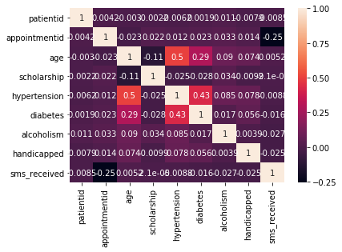

```python
corrmatrix=df.corr()
sns.heatmap(corrmatrix, annot=True)
plt.show()
```

### Research Question 1 - How big is the problem?, in other words, How many patients didn't show up to their appointment?

```python
total_noshow_formated=f"{total_noshow:,}"

total_patients=df.shape[0]
total_patients_formated=f"{total_patients:,}"
percentage=total_noshow/total_patients*100
percentage=percentage.astype(int)

print("Number of patients who didn't show up to their scheduled appointment are {} patient out of {} patient with represents {} % of the total patients.".format(total_noshow_formated, total_patients_formated,percentage))
```

```
Number of patients who didn't show up to their scheduled appointment are 21,675 patient out of 106,982 patient with represents 20 % of the total patients.
```

```
Text(0.5,1,'No Show Distribution')
```

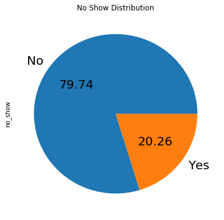

```python
df['no_show'].value_counts().plot(kind='pie', figsize=(6, 6),autopct='%.2f',fontsize=20)
plt.title('No Show Distribution')
```

### Research Question 2 - Do SMS reminders decrease the number of absences?

```python
#Sms_received Analysis
analyze('sms_received')
```

```
Distribution by sms_received,  With sms_received  32.3%  . With NO sms_received 67.7%
Percentage of No Show patients by sms_received , With sms_received  44.1%  . With NO sms_received 55.9%
Percentage of Show patients by sms_received , With sms_received  29.3%  . With NO sms_received 70.7%
```

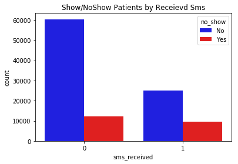

```python
sns_bar(df.sms_received,df.no_show,"Show/NoShow Patients by Receievd Sms",('blue','red'))
```

#### Answer to Research Question 2

Distribution by sms_received, With sms_received 32.3% . With NO sms_received 67.7%  
Percentage of No Show patients by sms_received , With sms_received 44.1% . With NO sms_received 55.9%  
Percentage of Show patients by sms_received , With sms_received 29.3% . With NO sms_received 70.7%

### Research Question 3 - Who in terms of age misses more appointments? (Age Distribution)

```python
# View the min, 25%, 50%, 75%, max of Age
df['age'].describe()
```

```
count    106982.000000
mean         38.316315
std          22.466023
min           1.000000
25%          19.000000
50%          38.000000
75%          56.000000
max         115.000000
Name: age, dtype: float64
```

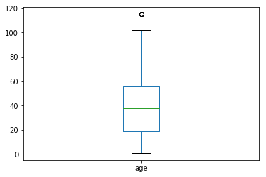

```python
# Plotting the min, 25%, 50%, 75%, max of Age
df['age'].plot.box()
```

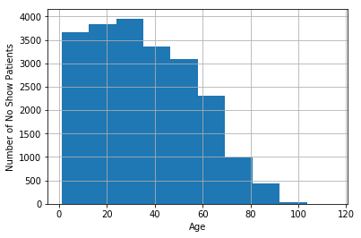

```python
#No Show Age Distribution

noshow_age_dist=df.query('no_show=="Yes"')
noshow_age_dist['age'].hist()
plt.xlabel('Age')
plt.ylabel('Number of No Show Patients');
```

```python
# Bin edges that will be used to "cut" the data into groups
bin_edges=[0,18,30,56,90,115]
bin_names=['children 1-18','youth 19-30','adults 31-55','senior 56-90','above 90']
df['age_group']=pd.cut(df['age'],bin_edges,labels=bin_names)
```

```python
#Calculating the percentage of no show by age group
noshow_byval('age_group')
```

```
Percentage of No Show patients by age_group , With age_group  26.3%  . With NO age_group 19.1%
```

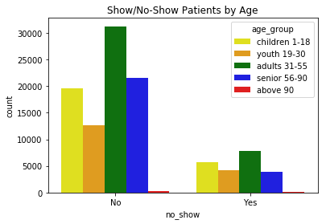

```python
# sns_bar(x_value,y_value,title)
sns_bar(df.no_show,df.age_group,'Show/No-Show Patients by Age',('yellow','orange','green','blue','red'))
```

#### Answer to Research Question 3

50% of the patients population in this dataset are of average age of 38.  
75% of the patients population in this dataset lie below the age of 56.

Percentage of no show by age group

1. children 1-18,... 26.3%
2. youth 19-30,... 19.1%
3. adults 31-55,... 35.9%
4. senior 56-90,.. 18.3%
5. above 90,... 0.3

### Research Question 4 - Are chronic illnesses like hypertension and diabetes affecting patient's absences?

```python
# Diabetes Analysis by distribution and percentages with or without
analyze('diabetes')
```

```
Distribution by diabetes,  With diabetes  7.4%  . With NO diabetes 92.6%
Percentage of No Show patients by diabetes , With diabetes  6.6%  . With NO diabetes 93.4%
Percentage of Show patients by diabetes , With diabetes  7.6%  . With NO diabetes 92.4%
```

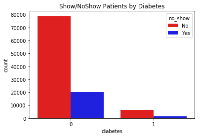

```python
sns_bar(df.diabetes,df.no_show,"Show/NoShow Patients by Diabetes",('red','blue'))
```

```python
# Hypertension Analysis by distribution and percentages of yes and no
analyze('hypertension')
```

```
Distribution by hypertension,  With hypertension  20.4%  . With NO hypertension 79.6%
Percentage of No Show patients by hypertension , With hypertension  17.4%  . With NO hypertension 82.6%
Percentage of Show patients by hypertension , With hypertension  21.1%  . With NO hypertension 78.9%
```

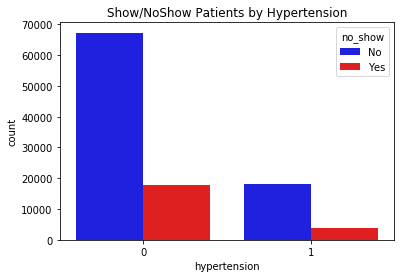

```python
sns_bar( df.hypertension,df.no_show,"Show/NoShow Patients by Hypertension",('blue','red'))
```

##### Answer to Research Question 4

Distribution by diabetes, With diabetes 7.4% . With NO diabetes 92.6%  
Percentage of No Show patients by diabetes , With diabetes 6.6% . With NO diabetes 93.4%  
Percentage of Show patients by diabetes , With diabetes 7.6% . With NO diabetes 92.4%  
Distribution by hypertension, With hypertension 20.4% . With NO hypertension 79.6%  
Percentage of No Show patients by hypertension , With hypertension 17.4% . With NO hypertension 82.6%  
Percentage of Show patients by hypertension , With hypertension 21.1% . With NO hypertension 78.9%

### Research Question 5- Is alcoholism a prominent factor in patient's absences? Are the absences frequent?

```python
# Alcoholism Analysis by distribution and percentages with or without
analyze('alcoholism')
```

```
Distribution by alcoholism,  With alcoholism  3.1%  . With NO alcoholism 96.9%
Percentage of No Show patients by alcoholism , With alcoholism  3.1%  . With NO alcoholism 96.9%
Percentage of Show patients by alcoholism , With alcoholism  3.1%  . With NO alcoholism 96.9%
```

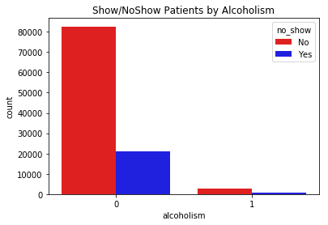

```python
sns_bar(df.alcoholism,df.no_show,"Show/NoShow Patients by Alcoholism",('red','blue'))
```

##### Answer to Research Question 5

Distribution by alcoholism, With alcoholism 3.1% . With NO alcoholism 96.9% Percentage of No Show patients by alcoholism , With alcoholism 3.1% . With NO alcoholism 96.9% Percentage of Show patients by alcoholism , With alcoholism 3.1% . With NO alcoholism 96.9%

### Research Question 6 - Do disabilities affect patient's absences?</li>

```python
# Handicapped Analysis by distribution and percentages with or without
analyze('handicapped')
```

```
Distribution by handicapped,  With handicapped  1.9%  . With NO handicapped 97.9%
Percentage of No Show patients by handicapped , With handicapped  1.7%  . With NO handicapped 98.1%
Percentage of Show patients by handicapped , With handicapped  2.0%  . With NO handicapped 97.9%
```

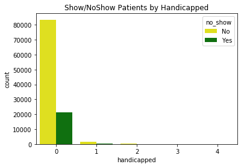

```python
sns_bar(df.handicapped,df.no_show,"Show/NoShow Patients by Handicapped",('yellow','green','blue','red'))
```

### Research Question 7 - Are no-show appointments associated with a certain gender?

```python
noshow_byval('gender')
```

```
Percentage of No Show patients by gender , With gender  65.8%  . With NO gender 34.2%
```

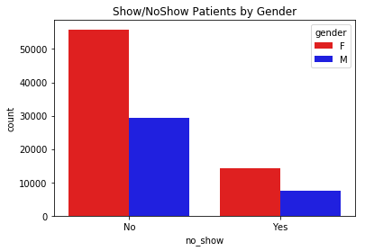

```python
sns_bar(df.no_show,df.gender,"Show/NoShow Patients by Gender",('red','blue'))
```

##### Answer to Research Question 7

65.8 % of patients who didn't show are females.  
34.2 % of patients who didn't show are males.

### Research Question 8 - Do patients who don't have scholarships affect their absences

```python
analyze('scholarship')
```

```
Distribution by scholarship,  With scholarship  10.1%  . With NO scholarship 89.9%
Percentage of No Show patients by scholarship , With scholarship  11.9%  . With NO scholarship 88.1%
Percentage of Show patients by scholarship , With scholarship  9.7%  . With NO scholarship 90.3%
```

```
Text(0.5,1,'Distribution by scholarship')
```

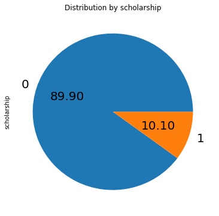

```python
#Scholarship Distribution Pie
df.scholarship.value_counts().plot(kind='pie', figsize=(6, 6),autopct='%.2f',fontsize=20)
plt.title('Distribution by scholarship')
```

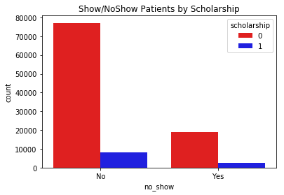

```python
sns_bar(df.no_show,df.scholarship,"Show/NoShow Patients by Scholarship",('red','blue'))
```

##### Answer to Research Question 8

Distribution by scholarship, With scholarship 10.1% . With NO scholarship 89.9%.  
Percentage of No Show patients by scholarship , With scholarship 11.9% . With NO scholarship 88.1%..  
Percentage of Show patients by scholarship , With scholarship 9.7% . With NO scholarship 90.3%..

### Research Question 9 - Is the period between scheduled day and appointment day affecting the number of no-show appointments?

```python
waiting_duration=df.appointmentday - df.scheduledday

df['waiting_duration']=waiting_duration.dt.days
```

```python
#Analyse waiting duration statistics
df['waiting_duration'].describe()
```

```
count    106982.000000
mean         10.167290
std          15.263631
min           0.000000
25%           0.000000
50%           4.000000
75%          14.000000
max         179.000000
Name: waiting_duration, dtype: float64
```

```python
#Grouping Waiting Duration
bin_edges=[-1,4,14,30,60,179]
bin_names=['0-4','5-14','15-30','31-60','61-179']
df['waiting_dur_group'] = pd.cut(df['waiting_duration'], bin_edges, labels=bin_names)
df.groupby('no_show')['waiting_dur_group'].value_counts()
```

```
no_show  waiting_dur_group
No       0-4                  50437
         5-14                 16929
         15-30                11260
         31-60                 5215
         61-179                1466
Yes      5-14                  6646
         0-4                   6232
         15-30                 5482
         31-60                 2737
         61-179                 578
Name: waiting_dur_group, dtype: int64
```

```python
 #Percentage by Characteristic for No Show
val='waiting_dur_group'
val_per=df[df.no_show == 'Yes'].groupby([val]).size()/total_noshow*100
val_per=round(val_per,1)

print("Percentage of No Show patients by {} , \n {}".format(val,val_per))
```

```
Percentage of No Show patients by waiting_dur_group ,
 waiting_dur_group
0-4       28.8
5-14      30.7
15-30     25.3
31-60     12.6
61-179     2.7
dtype: float64
```

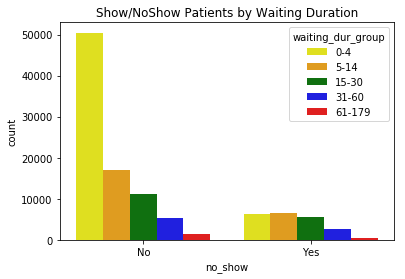

```python
sns_bar(df.no_show,df.waiting_dur_group,"Show/NoShow Patients by Waiting Duration",('yellow','orange','green','blue','red'))
```

##### Answer to Research Question 9

Percentage of No Show patients by waiting_dur_group:

| 0-4 | 28.8 |
| --- | --- |
| 5-14 | 30.7 |
| 15-30 | 25.3 |
| 31-60 | 12.6 |
| 61-179 | 2.7 |

### Research Question 10 - Do patients tend to skip their appointment if the clinic is crowded?

```python
#Number of appointments that were scheduled on the same day
same_day=df[df['scheduledday']==df['appointmentday']]
print("{} were scheduled on the same day of their appointment.".format(same_day.count()[0]))
```

```
37154 were scheduled on the same day of their appointment.
```

```
Text(0.5,1,'Appointments scheduled on the same day with No Show')
```

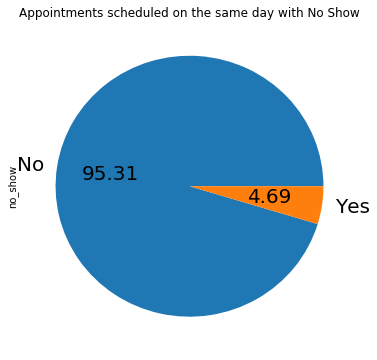

```python
#Visualizing Appointments scheduled on the same day with No Show
same_day.no_show.value_counts().plot(kind='pie', figsize=(6, 6),autopct='%.2f',fontsize=20)
plt.title('Appointments scheduled on the same day with No Show')
```

```python
#Number of appointments that were scheduled on the same day and didn't show
print ("Number of appointments that were scheduled on the same day and didn't shows are {}".format(same_day.no_show.value_counts()[1]))
```

```
Number of appointments that were scheduled on the same day and didn't shows are 1741
```

```python
#Percentage of appointments that were scheduled on the same day and didn't show
perc_sameday_noshow=round((same_day.no_show.value_counts()[1]/same_day.count()[0]*100))
print ("Percentage of appointments that were scheduled on the same day and didn't shows are {} % of total appointments that were scheduled on the same day".format(perc_sameday_noshow))
```

```
Percentage of appointments that were scheduled on the same day and didn't shows are 5.0 % of total appointments that were scheduled on the same day
```

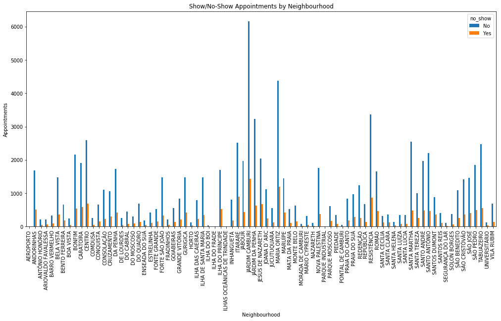

```python
#Show/No-Show Appointment by Neighbourhood
pd.crosstab(df['neighbourhood'],df['no_show']).plot(kind='bar',figsize=(17,8));
plt.title('Show/No-Show Appointments by Neighbourhood')
plt.xlabel('Neighbourhood')
plt.ylabel('Appointments');
```

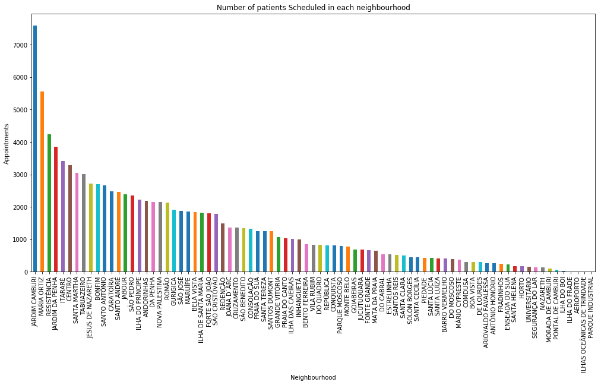

```python
#Number of patients Scheduled in each neighbourhood
df.neighbourhood.value_counts().plot(kind='bar',figsize=(17,8));
plt.title('Number of patients Scheduled in each neighbourhood')
plt.xlabel('Neighbourhood')
plt.ylabel('Appointments');
```

```python
#Investigate appointmentday to get the busiest day
df['appointmentday'].describe()
```

```
count         106982
unique            27
top       2016-06-06
freq            4528
Name: appointmentday, dtype: object
```

```python
#Busiest Day Investigation
d=dt.strptime("16-06-06", "%y-%m-%d")
df_busiest_day=df[df['appointmentday']==dt.date(d)]
```

```python
#Investigeting the top neighbourhood of the busiest day
df_busiest_day.neighbourhood.describe()
```

```
count               4528
unique                77
top       JARDIM CAMBURI
freq                 366
Name: neighbourhood, dtype: object
```

```python
#Getting the records of the Busiest clinic neighbourhood for the busiest day
top_loc_busiest_day=df_busiest_day.query("neighbourhood=='JARDIM CAMBURI'")
top_loc_busiest_day
```

|  | patientid | appointmentid | gender | scheduledday | appointmentday | age | neighbourhood | scholarship | hypertension | diabetes | alcoholism | handicapped | sms_received | no_show | age_group | waiting_duration | waiting_dur_group |
| --- | --- | --- | --- | --- | --- | --- | --- | --- | --- | --- | --- | --- | --- | --- | --- | --- | --- |
| 84589 | 6.371769e+13 | 5758383 | M | 2016-06-01 | 2016-06-06 | 8 | JARDIM CAMBURI | 0 | 0 | 0 | 0 | 0 | 1 | No | children 1-18 | 5 | 5-14 |
| 84590 | 1.683753e+11 | 5758380 | F | 2016-06-01 | 2016-06-06 | 10 | JARDIM CAMBURI | 0 | 0 | 0 | 0 | 0 | 1 | Yes | children 1-18 | 5 | 5-14 |
| 84605 | 1.326458e+13 | 5758436 | F | 2016-06-01 | 2016-06-06 | 74 | JARDIM CAMBURI | 0 | 0 | 0 | 0 | 0 | 1 | No | senior 56-90 | 5 | 5-14 |
| 84606 | 4.988423e+11 | 5758412 | F | 2016-06-01 | 2016-06-06 | 63 | JARDIM CAMBURI | 0 | 0 | 0 | 0 | 0 | 1 | Yes | senior 56-90 | 5 | 5-14 |
| 84608 | 4.968917e+14 | 5758409 | F | 2016-06-01 | 2016-06-06 | 63 | JARDIM CAMBURI | 0 | 0 | 0 | 0 | 0 | 0 | Yes | senior 56-90 | 5 | 5-14 |
| 84909 | 4.946722e+13 | 5763487 | F | 2016-06-02 | 2016-06-06 | 81 | JARDIM CAMBURI | 0 | 0 | 0 | 0 | 0 | 0 | No | senior 56-90 | 4 | 0-4 |
| 84910 | 2.274525e+11 | 5774107 | F | 2016-06-06 | 2016-06-06 | 44 | JARDIM CAMBURI | 0 | 0 | 0 | 0 | 0 | 0 | No | adults 31-55 | 0 | 0-4 |
| 84911 | 1.654963e+14 | 5758453 | M | 2016-06-01 | 2016-06-06 | 65 | JARDIM CAMBURI | 0 | 0 | 0 | 0 | 0 | 1 | No | senior 56-90 | 5 | 5-14 |
| 84912 | 5.752660e+13 | 5760041 | F | 2016-06-01 | 2016-06-06 | 54 | JARDIM CAMBURI | 0 | 0 | 0 | 0 | 0 | 1 | No | adults 31-55 | 5 | 5-14 |
| 84913 | 4.474864e+14 | 5777088 | F | 2016-06-06 | 2016-06-06 | 38 | JARDIM CAMBURI | 0 | 0 | 0 | 0 | 0 | 0 | No | adults 31-55 | 0 | 0-4 |
| 84914 | 6.243112e+14 | 5778212 | M | 2016-06-06 | 2016-06-06 | 53 | JARDIM CAMBURI | 0 | 1 | 0 | 0 | 0 | 0 | No | adults 31-55 | 0 | 0-4 |
| 85198 | 7.652684e+10 | 5777171 | F | 2016-06-06 | 2016-06-06 | 46 | JARDIM CAMBURI | 0 | 0 | 0 | 0 | 0 | 0 | Yes | adults 31-55 | 0 | 0-4 |
| 85199 | 6.921119e+14 | 5778636 | F | 2016-06-06 | 2016-06-06 | 86 | JARDIM CAMBURI | 0 | 0 | 0 | 0 | 0 | 0 | No | senior 56-90 | 0 | 0-4 |
| 85200 | 3.554653e+10 | 5778774 | F | 2016-06-06 | 2016-06-06 | 59 | JARDIM CAMBURI | 0 | 0 | 0 | 0 | 0 | 0 | No | senior 56-90 | 0 | 0-4 |
| 85201 | 1.886967e+14 | 5775742 | M | 2016-06-06 | 2016-06-06 | 42 | JARDIM CAMBURI | 0 | 0 | 0 | 0 | 0 | 0 | No | adults 31-55 | 0 | 0-4 |
| 85202 | 6.781743e+12 | 5778805 | F | 2016-06-06 | 2016-06-06 | 51 | JARDIM CAMBURI | 0 | 0 | 0 | 0 | 0 | 0 | No | adults 31-55 | 0 | 0-4 |
| 85203 | 5.159759e+12 | 5779044 | F | 2016-06-06 | 2016-06-06 | 69 | JARDIM CAMBURI | 0 | 1 | 0 | 0 | 0 | 0 | No | senior 56-90 | 0 | 0-4 |
| 85205 | 1.918440e+14 | 5779068 | M | 2016-06-06 | 2016-06-06 | 57 | JARDIM CAMBURI | 0 | 0 | 0 | 0 | 0 | 0 | No | senior 56-90 | 0 | 0-4 |
| 85206 | 1.587524e+13 | 5773033 | F | 2016-06-03 | 2016-06-06 | 56 | JARDIM CAMBURI | 0 | 1 | 0 | 0 | 0 | 0 | No | adults 31-55 | 3 | 0-4 |
| 85207 | 9.124426e+14 | 5765016 | M | 2016-06-02 | 2016-06-06 | 61 | JARDIM CAMBURI | 0 | 0 | 0 | 0 | 0 | 1 | No | senior 56-90 | 4 | 0-4 |
| 85208 | 5.932856e+10 | 5779191 | F | 2016-06-06 | 2016-06-06 | 54 | JARDIM CAMBURI | 0 | 0 | 0 | 0 | 0 | 0 | No | adults 31-55 | 0 | 0-4 |
| 85748 | 9.734292e+12 | 5771746 | M | 2016-06-03 | 2016-06-06 | 71 | JARDIM CAMBURI | 0 | 0 | 0 | 0 | 0 | 1 | No | senior 56-90 | 3 | 0-4 |
| 85749 | 6.515870e+13 | 5776997 | F | 2016-06-06 | 2016-06-06 | 33 | JARDIM CAMBURI | 0 | 0 | 0 | 0 | 0 | 0 | No | adults 31-55 | 0 | 0-4 |
| 85750 | 9.324515e+13 | 5771293 | F | 2016-06-03 | 2016-06-06 | 36 | JARDIM CAMBURI | 0 | 0 | 0 | 0 | 0 | 1 | No | adults 31-55 | 3 | 0-4 |
| 85751 | 6.513376e+12 | 5777309 | F | 2016-06-06 | 2016-06-06 | 22 | JARDIM CAMBURI | 0 | 0 | 0 | 0 | 0 | 0 | No | youth 19-30 | 0 | 0-4 |
| 85752 | 2.446869e+13 | 5777393 | F | 2016-06-06 | 2016-06-06 | 38 | JARDIM CAMBURI | 0 | 0 | 0 | 0 | 0 | 0 | No | adults 31-55 | 0 | 0-4 |
| 85753 | 9.483467e+12 | 5772770 | F | 2016-06-03 | 2016-06-06 | 65 | JARDIM CAMBURI | 0 | 0 | 0 | 0 | 0 | 0 | No | senior 56-90 | 3 | 0-4 |
| 85754 | 6.491962e+13 | 5778184 | M | 2016-06-06 | 2016-06-06 | 64 | JARDIM CAMBURI | 0 | 0 | 0 | 0 | 0 | 0 | No | senior 56-90 | 0 | 0-4 |
| 85755 | 6.354497e+12 | 5766766 | F | 2016-06-02 | 2016-06-06 | 77 | JARDIM CAMBURI | 0 | 0 | 0 | 0 | 0 | 1 | Yes | senior 56-90 | 4 | 0-4 |
| 85778 | 8.685538e+14 | 5778563 | F | 2016-06-06 | 2016-06-06 | 57 | JARDIM CAMBURI | 0 | 0 | 0 | 0 | 0 | 0 | No | senior 56-90 | 0 | 0-4 |
| ... | ... | ... | ... | ... | ... | ... | ... | ... | ... | ... | ... | ... | ... | ... | ... | ... | ... |
| 105181 | 9.348643e+13 | 5761680 | F | 2016-06-02 | 2016-06-06 | 80 | JARDIM CAMBURI | 0 | 0 | 0 | 0 | 0 | 1 | No | senior 56-90 | 4 | 0-4 |
| 105464 | 2.859114e+14 | 5704894 | F | 2016-05-16 | 2016-06-06 | 76 | JARDIM CAMBURI | 0 | 0 | 0 | 0 | 0 | 0 | No | senior 56-90 | 21 | 15-30 |
| 105465 | 3.937113e+13 | 5733025 | F | 2016-05-24 | 2016-06-06 | 85 | JARDIM CAMBURI | 0 | 0 | 0 | 0 | 0 | 1 | Yes | senior 56-90 | 13 | 5-14 |
| 106656 | 7.179798e+12 | 5774900 | F | 2016-06-06 | 2016-06-06 | 67 | JARDIM CAMBURI | 0 | 0 | 0 | 0 | 0 | 0 | No | senior 56-90 | 0 | 0-4 |
| 106820 | 9.334735e+13 | 5766672 | F | 2016-06-02 | 2016-06-06 | 64 | JARDIM CAMBURI | 0 | 0 | 0 | 0 | 0 | 1 | No | senior 56-90 | 4 | 0-4 |
| 106954 | 7.475675e+14 | 5763267 | F | 2016-06-02 | 2016-06-06 | 28 | JARDIM CAMBURI | 0 | 0 | 0 | 0 | 0 | 1 | No | youth 19-30 | 4 | 0-4 |
| 107111 | 7.579746e+13 | 5774827 | M | 2016-06-06 | 2016-06-06 | 49 | JARDIM CAMBURI | 0 | 0 | 0 | 0 | 0 | 0 | No | adults 31-55 | 0 | 0-4 |
| 107624 | 9.838876e+13 | 5761602 | F | 2016-06-02 | 2016-06-06 | 55 | JARDIM CAMBURI | 0 | 0 | 0 | 0 | 0 | 1 | Yes | adults 31-55 | 4 | 0-4 |
| 107770 | 4.568515e+14 | 5761796 | M | 2016-06-02 | 2016-06-06 | 62 | JARDIM CAMBURI | 0 | 0 | 0 | 0 | 0 | 1 | No | senior 56-90 | 4 | 0-4 |
| 107775 | 6.325357e+11 | 5761767 | F | 2016-06-02 | 2016-06-06 | 54 | JARDIM CAMBURI | 0 | 0 | 0 | 0 | 0 | 1 | No | adults 31-55 | 4 | 0-4 |
| 108706 | 7.579746e+13 | 5778113 | M | 2016-06-06 | 2016-06-06 | 49 | JARDIM CAMBURI | 0 | 0 | 0 | 0 | 0 | 0 | No | adults 31-55 | 0 | 0-4 |
| 108863 | 7.579746e+13 | 5776314 | M | 2016-06-06 | 2016-06-06 | 49 | JARDIM CAMBURI | 0 | 0 | 0 | 0 | 0 | 0 | No | adults 31-55 | 0 | 0-4 |
| 108865 | 7.579746e+13 | 5776311 | M | 2016-06-06 | 2016-06-06 | 49 | JARDIM CAMBURI | 0 | 0 | 0 | 0 | 0 | 0 | No | adults 31-55 | 0 | 0-4 |
| 108918 | 9.519375e+12 | 5761597 | F | 2016-06-02 | 2016-06-06 | 65 | JARDIM CAMBURI | 0 | 0 | 0 | 0 | 0 | 1 | No | senior 56-90 | 4 | 0-4 |
| 108921 | 6.269779e+12 | 5761594 | F | 2016-06-02 | 2016-06-06 | 64 | JARDIM CAMBURI | 0 | 0 | 0 | 0 | 0 | 1 | No | senior 56-90 | 4 | 0-4 |
| 109248 | 3.741693e+12 | 5744945 | M | 2016-05-30 | 2016-06-06 | 56 | JARDIM CAMBURI | 0 | 1 | 0 | 0 | 0 | 1 | No | adults 31-55 | 7 | 5-14 |
| 109250 | 2.187692e+10 | 5744908 | M | 2016-05-30 | 2016-06-06 | 74 | JARDIM CAMBURI | 0 | 0 | 0 | 0 | 0 | 1 | No | senior 56-90 | 7 | 5-14 |
| 109429 | 5.371117e+13 | 5761731 | M | 2016-06-02 | 2016-06-06 | 64 | JARDIM CAMBURI | 0 | 0 | 1 | 0 | 0 | 1 | No | senior 56-90 | 4 | 0-4 |
| 109448 | 2.798549e+14 | 5767056 | F | 2016-06-02 | 2016-06-06 | 54 | JARDIM CAMBURI | 0 | 0 | 0 | 0 | 0 | 1 | No | adults 31-55 | 4 | 0-4 |
| 109589 | 7.293555e+10 | 5766792 | F | 2016-06-02 | 2016-06-06 | 31 | JARDIM CAMBURI | 0 | 0 | 0 | 0 | 0 | 1 | Yes | adults 31-55 | 4 | 0-4 |
| 109591 | 8.756188e+12 | 5766728 | F | 2016-06-02 | 2016-06-06 | 52 | JARDIM CAMBURI | 0 | 0 | 0 | 0 | 0 | 1 | No | adults 31-55 | 4 | 0-4 |
| 109592 | 5.349183e+11 | 5766789 | F | 2016-06-02 | 2016-06-06 | 33 | JARDIM CAMBURI | 0 | 0 | 0 | 0 | 0 | 1 | No | adults 31-55 | 4 | 0-4 |
| 109873 | 8.941671e+10 | 5767488 | F | 2016-06-02 | 2016-06-06 | 37 | JARDIM CAMBURI | 0 | 0 | 0 | 0 | 0 | 1 | No | adults 31-55 | 4 | 0-4 |
| 109989 | 4.451462e+12 | 5765856 | F | 2016-06-02 | 2016-06-06 | 64 | JARDIM CAMBURI | 0 | 0 | 0 | 0 | 0 | 1 | No | senior 56-90 | 4 | 0-4 |
| 109992 | 4.968917e+14 | 5765854 | F | 2016-06-02 | 2016-06-06 | 63 | JARDIM CAMBURI | 0 | 0 | 0 | 0 | 0 | 1 | Yes | senior 56-90 | 4 | 0-4 |
| 109993 | 8.413495e+13 | 5765852 | F | 2016-06-02 | 2016-06-06 | 63 | JARDIM CAMBURI | 0 | 0 | 0 | 0 | 0 | 1 | No | senior 56-90 | 4 | 0-4 |
| 109994 | 4.555823e+13 | 5765851 | F | 2016-06-02 | 2016-06-06 | 11 | JARDIM CAMBURI | 0 | 0 | 0 | 0 | 0 | 1 | No | children 1-18 | 4 | 0-4 |
| 110069 | 3.529287e+11 | 5758777 | F | 2016-06-01 | 2016-06-06 | 45 | JARDIM CAMBURI | 0 | 0 | 0 | 0 | 0 | 1 | No | adults 31-55 | 5 | 5-14 |
| 110140 | 2.497884e+12 | 5766337 | F | 2016-06-02 | 2016-06-06 | 52 | JARDIM CAMBURI | 0 | 0 | 0 | 0 | 0 | 1 | No | adults 31-55 | 4 | 0-4 |
| 110252 | 5.753389e+12 | 5774714 | M | 2016-06-06 | 2016-06-06 | 17 | JARDIM CAMBURI | 0 | 0 | 0 | 0 | 0 | 0 | No | children 1-18 | 0 | 0-4 |

366 rows × 17 columns

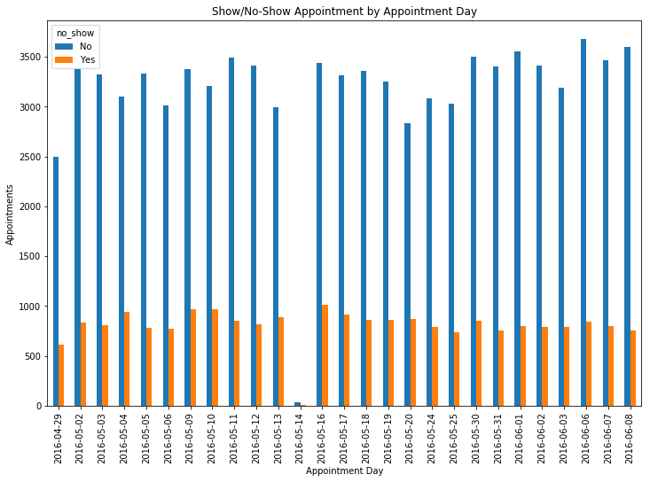

```python
#Show/No-Show Appointment by Appointment Day
pd.crosstab(df['appointmentday'],df['no_show']).plot(kind='bar',figsize=(12,8));
plt.title('Show/No-Show Appointment by Appointment Day')
plt.xlabel('Appointment Day')
plt.ylabel('Appointments');
```

```python
#Finding if there are duplciated patients records in that day
patients_records_count=top_loc_busiest_day.groupby('patientid').count()['appointmentid']
duplicates_count=patients_records_count>1
```

```python
#Number of patients with duplicated records
duplicates_count.value_counts()
```

```
False    285
True      37
Name: appointmentid, dtype: int64
```

```python
#Number of patients who didn't show up on the busiest days in the top neighbourhood
noshow_busyday=top_loc_busiest_day.no_show
noshow_busyday.value_counts()
```

```
No     300
Yes     66
Name: no_show, dtype: int64
```

```python
#Percentage of patients who didn't show up on the busiest days in the top neighbourhood
percent= int(round( 66/300*100,0))
print("{}% of patients didn't show up on the busiest day.".format(percent))
```

```
22% of patients didn't show up on the busiest day.
```

```python
#Number of patients who didn't show up on the busiest days in the top neighbourhood
total_dup=top_loc_busiest_day.groupby('patientid').count()['appointmentid']>1
total_dup.value_counts()
```

```
False    285
True      37
Name: appointmentid, dtype: int64
```

```python
#Percentage of patients who didn't show up on the busiest days
66/366*100
```

```
18.0327868852459
```

```python
#Percentage of duplciated patients records in that day
37/366*100
```

```
10.10928961748634
```

### An important finding:

10% duplcaited patient id in the busiest day in the top neighbourhood  
18% didn't show up on that day  
Accordingly, we need to investigate the dataset again for duplicated values by patientid and appointmentday

```python
#Number of duplicated records by patientid and appointmentday
duplicated_rows=df[df.duplicated(subset=['patientid','appointmentday'])]
duplicated_rows.count()[0]
```

```
8531
```

```python
#df.drop_duplicates(subset=['patientid','appointmentday'],inplace=True)
```

```python
#Number of duplicated records by patientid and appointmentday with no show
duplicated_rows.no_show.value_counts()
```

```
No     6676
Yes    1855
Name: no_show, dtype: int64
```

```python
print(" The duplicated records by patientid and appointmentday is around {} % out of the patients who didn't show .".format( round(1855/22000*100)))
```

```
 The duplicated records by patientid and appointmentday is around 8 % out of the patients who didn't show .
```

```python
#Explore all duplciated rows
d=df[df.duplicated(subset=['patientid','appointmentday'],keep=False)]
d.sort_values(by=['patientid','appointmentday'])
```

|  | patientid | appointmentid | gender | scheduledday | appointmentday | age | neighbourhood | scholarship | hypertension | diabetes | alcoholism | handicapped | sms_received | no_show | age_group | waiting_duration | waiting_dur_group |
| --- | --- | --- | --- | --- | --- | --- | --- | --- | --- | --- | --- | --- | --- | --- | --- | --- | --- |
| 43575 | 1.781682e+08 | 5568452 | F | 2016-04-11 | 2016-05-02 | 62 | MARUÍPE | 0 | 1 | 0 | 0 | 0 | 1 | No | senior 56-90 | 21 | 15-30 |
| 55391 | 1.781682e+08 | 5647593 | F | 2016-05-02 | 2016-05-02 | 62 | MARUÍPE | 0 | 1 | 0 | 0 | 0 | 0 | No | senior 56-90 | 0 | 0-4 |
| 50732 | 5.225847e+08 | 5624326 | F | 2016-04-26 | 2016-05-16 | 3 | SANTA CECÍLIA | 0 | 0 | 0 | 0 | 0 | 0 | Yes | children 1-18 | 20 | 15-30 |
| 50736 | 5.225847e+08 | 5624330 | F | 2016-04-26 | 2016-05-16 | 3 | SANTA CECÍLIA | 0 | 0 | 0 | 0 | 0 | 0 | Yes | children 1-18 | 20 | 15-30 |
| 11288 | 5.551995e+08 | 5743075 | F | 2016-05-30 | 2016-05-30 | 74 | JUCUTUQUARA | 0 | 0 | 0 | 0 | 0 | 0 | No | senior 56-90 | 0 | 0-4 |
| 30589 | 5.551995e+08 | 5743496 | F | 2016-05-30 | 2016-05-30 | 74 | JUCUTUQUARA | 0 | 0 | 0 | 0 | 0 | 0 | No | senior 56-90 | 0 | 0-4 |
| 51017 | 7.241189e+08 | 5678767 | M | 2016-05-10 | 2016-05-10 | 80 | PIEDADE | 0 | 1 | 0 | 1 | 0 | 0 | No | senior 56-90 | 0 | 0-4 |
| 51455 | 7.241189e+08 | 5680047 | M | 2016-05-10 | 2016-05-10 | 80 | PIEDADE | 0 | 1 | 0 | 1 | 0 | 0 | No | senior 56-90 | 0 | 0-4 |
| 51457 | 7.241189e+08 | 5680058 | M | 2016-05-10 | 2016-05-10 | 80 | PIEDADE | 0 | 1 | 0 | 1 | 0 | 0 | No | senior 56-90 | 0 | 0-4 |
| 51459 | 7.241189e+08 | 5680061 | M | 2016-05-10 | 2016-05-10 | 80 | PIEDADE | 0 | 1 | 0 | 1 | 0 | 0 | No | senior 56-90 | 0 | 0-4 |
| 38741 | 7.571455e+08 | 5674161 | F | 2016-05-09 | 2016-05-19 | 49 | SANTA TEREZA | 0 | 0 | 0 | 0 | 0 | 0 | Yes | adults 31-55 | 10 | 5-14 |
| 38765 | 7.571455e+08 | 5716737 | F | 2016-05-19 | 2016-05-19 | 49 | SANTA TEREZA | 0 | 0 | 0 | 0 | 0 | 0 | No | adults 31-55 | 0 | 0-4 |
| 91871 | 8.166392e+08 | 5786987 | F | 2016-06-08 | 2016-06-08 | 19 | JARDIM DA PENHA | 0 | 0 | 0 | 0 | 0 | 0 | No | youth 19-30 | 0 | 0-4 |
| 96541 | 8.166392e+08 | 5785895 | F | 2016-06-08 | 2016-06-08 | 19 | JARDIM DA PENHA | 0 | 0 | 0 | 0 | 0 | 0 | No | youth 19-30 | 0 | 0-4 |
| 46858 | 8.384423e+08 | 5675552 | F | 2016-05-09 | 2016-05-09 | 82 | TABUAZEIRO | 0 | 1 | 0 | 0 | 1 | 0 | No | senior 56-90 | 0 | 0-4 |
| 71395 | 8.384423e+08 | 5646307 | F | 2016-05-02 | 2016-05-09 | 82 | TABUAZEIRO | 0 | 1 | 0 | 0 | 1 | 0 | No | senior 56-90 | 7 | 5-14 |
| 17564 | 8.688158e+08 | 5695644 | F | 2016-05-13 | 2016-05-13 | 1 | SANTO ANDRÉ | 0 | 0 | 0 | 0 | 0 | 0 | No | children 1-18 | 0 | 0-4 |
| 52944 | 8.688158e+08 | 5695472 | F | 2016-05-13 | 2016-05-13 | 1 | SANTO ANDRÉ | 0 | 0 | 0 | 0 | 0 | 0 | No | children 1-18 | 0 | 0-4 |
| 22371 | 9.346450e+08 | 5630787 | F | 2016-04-27 | 2016-05-02 | 61 | RESISTÊNCIA | 0 | 0 | 0 | 0 | 0 | 1 | No | senior 56-90 | 5 | 5-14 |
| 22377 | 9.346450e+08 | 5630788 | F | 2016-04-27 | 2016-05-02 | 61 | RESISTÊNCIA | 0 | 0 | 0 | 0 | 0 | 0 | No | senior 56-90 | 5 | 5-14 |
| 18255 | 9.346450e+08 | 5650755 | F | 2016-05-03 | 2016-05-04 | 61 | RESISTÊNCIA | 0 | 0 | 0 | 0 | 0 | 0 | No | senior 56-90 | 1 | 0-4 |
| 18256 | 9.346450e+08 | 5650756 | F | 2016-05-03 | 2016-05-04 | 61 | RESISTÊNCIA | 0 | 0 | 0 | 0 | 0 | 0 | No | senior 56-90 | 1 | 0-4 |
| 2034 | 9.673878e+08 | 5621688 | M | 2016-04-26 | 2016-04-29 | 38 | GURIGICA | 0 | 0 | 0 | 0 | 0 | 0 | No | adults 31-55 | 3 | 0-4 |
| 2040 | 9.673878e+08 | 5621683 | M | 2016-04-26 | 2016-04-29 | 38 | GURIGICA | 0 | 0 | 0 | 0 | 0 | 1 | No | adults 31-55 | 3 | 0-4 |
| 22103 | 9.673878e+08 | 5643131 | M | 2016-05-02 | 2016-05-02 | 38 | GURIGICA | 0 | 0 | 0 | 0 | 0 | 0 | No | adults 31-55 | 0 | 0-4 |
| 44607 | 9.673878e+08 | 5642029 | M | 2016-04-29 | 2016-05-02 | 38 | GURIGICA | 0 | 0 | 0 | 0 | 0 | 1 | No | adults 31-55 | 3 | 0-4 |
| 76990 | 9.952779e+08 | 5670930 | F | 2016-05-06 | 2016-05-06 | 33 | BONFIM | 0 | 0 | 0 | 0 | 0 | 0 | No | adults 31-55 | 0 | 0-4 |
| 81150 | 9.952779e+08 | 5670830 | F | 2016-05-06 | 2016-05-06 | 33 | BONFIM | 0 | 0 | 0 | 0 | 0 | 0 | No | adults 31-55 | 0 | 0-4 |
| 12274 | 9.976945e+08 | 5683603 | F | 2016-05-11 | 2016-05-11 | 54 | SANTA MARTHA | 0 | 0 | 0 | 0 | 0 | 0 | No | adults 31-55 | 0 | 0-4 |
| 80158 | 9.976945e+08 | 5676579 | F | 2016-05-09 | 2016-05-11 | 54 | SANTA MARTHA | 0 | 0 | 0 | 0 | 0 | 0 | No | adults 31-55 | 2 | 0-4 |
| ... | ... | ... | ... | ... | ... | ... | ... | ... | ... | ... | ... | ... | ... | ... | ... | ... | ... |
| 81254 | 9.956116e+14 | 5673997 | F | 2016-05-09 | 2016-05-13 | 29 | ILHA DAS CAIEIRAS | 1 | 0 | 0 | 0 | 0 | 0 | No | youth 19-30 | 4 | 0-4 |
| 81257 | 9.956116e+14 | 5673998 | F | 2016-05-09 | 2016-05-13 | 29 | ILHA DAS CAIEIRAS | 1 | 0 | 0 | 0 | 0 | 0 | No | youth 19-30 | 4 | 0-4 |
| 68754 | 9.961496e+14 | 5651390 | F | 2016-05-03 | 2016-05-19 | 38 | UNIVERSITÁRIO | 0 | 0 | 0 | 0 | 0 | 0 | No | adults 31-55 | 16 | 15-30 |
| 72242 | 9.961496e+14 | 5717809 | F | 2016-05-19 | 2016-05-19 | 38 | UNIVERSITÁRIO | 0 | 0 | 0 | 0 | 0 | 0 | No | adults 31-55 | 0 | 0-4 |
| 16303 | 9.963129e+14 | 5692212 | F | 2016-05-12 | 2016-05-17 | 85 | CARATOÍRA | 0 | 1 | 1 | 0 | 0 | 0 | No | senior 56-90 | 5 | 5-14 |
| 19554 | 9.963129e+14 | 5695417 | F | 2016-05-13 | 2016-05-17 | 85 | CARATOÍRA | 0 | 1 | 1 | 0 | 0 | 0 | No | senior 56-90 | 4 | 0-4 |
| 32334 | 9.965172e+14 | 5643050 | M | 2016-05-02 | 2016-05-03 | 69 | CENTRO | 0 | 1 | 0 | 0 | 0 | 0 | No | senior 56-90 | 1 | 0-4 |
| 36600 | 9.965172e+14 | 5645541 | M | 2016-05-02 | 2016-05-03 | 69 | CENTRO | 0 | 1 | 0 | 0 | 0 | 0 | No | senior 56-90 | 1 | 0-4 |
| 57551 | 9.966876e+14 | 5652866 | M | 2016-05-03 | 2016-05-04 | 47 | BONFIM | 0 | 1 | 1 | 0 | 0 | 0 | No | adults 31-55 | 1 | 0-4 |
| 57584 | 9.966876e+14 | 5652924 | M | 2016-05-03 | 2016-05-04 | 47 | BONFIM | 0 | 1 | 1 | 0 | 0 | 0 | No | adults 31-55 | 1 | 0-4 |
| 99944 | 9.968524e+14 | 5770646 | F | 2016-06-03 | 2016-06-03 | 36 | RESISTÊNCIA | 0 | 0 | 0 | 0 | 0 | 0 | No | adults 31-55 | 0 | 0-4 |
| 110458 | 9.968524e+14 | 5770114 | F | 2016-06-03 | 2016-06-03 | 36 | RESISTÊNCIA | 0 | 0 | 0 | 0 | 0 | 0 | No | adults 31-55 | 0 | 0-4 |
| 63516 | 9.972476e+14 | 5735764 | M | 2016-05-25 | 2016-05-25 | 73 | DA PENHA | 0 | 1 | 0 | 0 | 0 | 0 | No | senior 56-90 | 0 | 0-4 |
| 79352 | 9.972476e+14 | 5740187 | M | 2016-05-25 | 2016-05-25 | 73 | DA PENHA | 0 | 1 | 0 | 0 | 0 | 0 | No | senior 56-90 | 0 | 0-4 |
| 26593 | 9.975988e+14 | 5686853 | F | 2016-05-11 | 2016-05-16 | 18 | ILHA DAS CAIEIRAS | 0 | 0 | 0 | 0 | 0 | 0 | Yes | children 1-18 | 5 | 5-14 |
| 50846 | 9.975988e+14 | 5701690 | F | 2016-05-16 | 2016-05-16 | 18 | ILHA DAS CAIEIRAS | 0 | 0 | 0 | 0 | 0 | 0 | No | children 1-18 | 0 | 0-4 |
| 18003 | 9.975988e+14 | 5712437 | F | 2016-05-18 | 2016-05-18 | 18 | ILHA DAS CAIEIRAS | 0 | 0 | 0 | 0 | 0 | 0 | No | children 1-18 | 0 | 0-4 |
| 69310 | 9.975988e+14 | 5713473 | F | 2016-05-18 | 2016-05-18 | 18 | ILHA DAS CAIEIRAS | 0 | 0 | 0 | 0 | 0 | 0 | No | children 1-18 | 0 | 0-4 |
| 32851 | 9.986957e+14 | 5607486 | F | 2016-04-20 | 2016-05-17 | 49 | ENSEADA DO SUÁ | 1 | 1 | 0 | 1 | 0 | 0 | Yes | adults 31-55 | 27 | 15-30 |
| 57534 | 9.986957e+14 | 5709326 | F | 2016-05-17 | 2016-05-17 | 49 | ENSEADA DO SUÁ | 1 | 1 | 0 | 1 | 0 | 0 | No | adults 31-55 | 0 | 0-4 |
| 51042 | 9.988821e+14 | 5650930 | F | 2016-05-03 | 2016-05-03 | 5 | MARIA ORTIZ | 0 | 0 | 0 | 0 | 0 | 0 | No | children 1-18 | 0 | 0-4 |
| 68524 | 9.988821e+14 | 5650628 | F | 2016-05-03 | 2016-05-03 | 5 | MARIA ORTIZ | 0 | 0 | 0 | 0 | 0 | 0 | No | children 1-18 | 0 | 0-4 |
| 70583 | 9.992778e+14 | 5664282 | M | 2016-05-05 | 2016-05-05 | 21 | JARDIM DA PENHA | 0 | 0 | 0 | 0 | 0 | 0 | No | youth 19-30 | 0 | 0-4 |
| 70584 | 9.992778e+14 | 5664279 | M | 2016-05-05 | 2016-05-05 | 21 | JARDIM DA PENHA | 0 | 0 | 0 | 0 | 0 | 0 | No | youth 19-30 | 0 | 0-4 |
| 77678 | 9.993364e+14 | 5663815 | M | 2016-05-05 | 2016-05-05 | 40 | ITARARÉ | 1 | 0 | 0 | 0 | 0 | 0 | No | adults 31-55 | 0 | 0-4 |
| 81651 | 9.993364e+14 | 5656514 | M | 2016-05-04 | 2016-05-05 | 40 | ITARARÉ | 1 | 0 | 0 | 0 | 0 | 0 | No | adults 31-55 | 1 | 0-4 |
| 51004 | 9.996275e+14 | 5697831 | M | 2016-05-14 | 2016-05-16 | 77 | PIEDADE | 0 | 1 | 1 | 0 | 0 | 0 | Yes | senior 56-90 | 2 | 0-4 |
| 51006 | 9.996275e+14 | 5699863 | M | 2016-05-16 | 2016-05-16 | 77 | PIEDADE | 0 | 1 | 1 | 0 | 0 | 0 | No | senior 56-90 | 0 | 0-4 |
| 32023 | 9.999320e+14 | 5710157 | M | 2016-05-17 | 2016-05-17 | 90 | JABOUR | 0 | 0 | 0 | 0 | 0 | 0 | No | senior 56-90 | 0 | 0-4 |
| 62099 | 9.999320e+14 | 5700484 | M | 2016-05-16 | 2016-05-17 | 90 | JABOUR | 0 | 0 | 0 | 0 | 0 | 0 | No | senior 56-90 | 1 | 0-4 |

15833 rows × 17 columns

```python
df.columns
```

```
Index(['patientid', 'appointmentid', 'gender', 'scheduledday',
       'appointmentday', 'age', 'neighbourhood', 'scholarship', 'hypertension',
       'diabetes', 'alcoholism', 'handicapped', 'sms_received', 'no_show',
       'age_group', 'waiting_duration', 'waiting_dur_group'],
      dtype='object')
```

```python
explore=df[df.duplicated(subset=['patientid','appointmentday'],keep=False)]
explore.sort_values(by=['patientid','appointmentday'])

#Check if the scheduled days of duplicated values are the same day
duplicates_on_diff_scheduledday=explore.groupby(['patientid','appointmentday']).scheduledday.describe().unique>2
y=duplicates_on_diff_scheduledday.count()
duplicates_on_diff_scheduledday=duplicates_on_diff_scheduledday.value_counts()
x=duplicates_on_diff_scheduledday[1]

print('{} out of {} were registered on the same day'.format(x,y))
```

```
54 out of 7302 were registered on the same day
```

## Conclusions

This dataset collects information from 100k medical appointments in Brazil and is focused on the question of whether or not patients show up for their appointment. A number of characteristics about the patient are included in each row.

The research questions with their findings are as follows:

> 1- How big is the problem?, in other words, How many patients didn't show up to their appointment?  
> Number of patients who didn't show up to their scheduled appointment are 21,675 patient out of 106,982 patient after data cleaning with represents 20 % of the total patients.

> 2 - Do SMS reminders decrease the number of absences?

> Distribution of sms_received, for YES 32.3% and for NO 67.7%.  
> Percentage of sms_received with No-Show, for YES 44.1% and for NO 55.9%.  
> Percentage of sms_received with Show, for YES 29.3% and for NO 70.7%.

> 3 - Who in terms of age misses more appointments? (Age Distribution)

> 50% of the patients population in this dataset are of average age of 38.  
> 75% of the patients population in this dataset lie below the age of 56.

> Calculating the percentage of no show by age group

> children 1-18,... 26.3%  
> youth 19-30,... 19.1%  
> adults 31-55,... 35.9%  
> senior 56-90,.. 18.3%  
> above 90,... 0.3%

> 4 - Are chronic illnesses like hypertension and diabetes affecting patient's absences?  
> 93.4 % of patients who didn't show don't have diabetes.  
> 82.6 % of patients who didn't show don't have hypertension.

> 5 - Is alcoholism a prominent factor in patient's absences?  
> Distribution by alcoholism, With alcoholism 3.1% . With NO alcoholism 96.9%  
> Percentage of No Show patients by alcoholism , With alcoholism 3.1% . With NO alcoholism 96.9%  
> Percentage of Show patients by alcoholism , With alcoholism 3.1% . With NO alcoholism 96.9%

> 7 - Are no-show appointments associated with a certain gender?  
> 65.8 % of patients who didn't show are females.  
> 34.2 % of patients who didn't show are males.

> 8 - Do patients who don't have scholarships affect their absences?  
> 88.1 % of patients who didn't show don't have scholarship.

> 9 - Is the period between scheduled day and appointment day affecting the number of no-show appointments?  
> Percentage of No Show patients by waiting_dur_group:

> | 0-4 | 28.8 |
> | --- | --- |
> | 5-14 | 30.7 |
> | 15-30 | 25.3 |
> | 31-60 | 12.6 |
> | 61-179 | 2.7 |

### Limitations:

> The age 0 was not clear if it is for infants or errant data.  
> There were 8531 duplciated records by patientid and appointment day and 1855 records out of which didn't attend their appointment.  
> The medical specialty which each patient is scheduled to is not stated which is important to calculate the crowdness at each medical speciality clinic because if we have for instance 10 patients scheduled to different medical specialities which in return to different physians and therfore different waiting time .  
> The number of hospitals\clinics available in each neighbourhood is not stated.  
> Calculating the busiest day or month is irrelevant due to the absence of the medical speciality each patient is scheduled to and the number of clinics\hospitals in each neighbourhood.  
> Some neighbourhoods are with few medical records.